# R Notebook

**Principles of Data Visualization and Introduction to ggplot2**

I have provided you with data about the 5,000 fastest growing companies in the US, as compiled by Inc. magazine. lets read this in:

```r
inc <- read.csv("https://raw.githubusercontent.com/charleyferrari/CUNY_DATA_608/master/module1/Data/inc5000_data.csv", header= TRUE)
```

And lets preview this data:

```r
head(inc)
```

|  | Rank | Name | Growth_Rate | Revenue | Industry | Employees | City | State |
| --- | --- | --- | --- | --- | --- | --- | --- | --- |
| 1 | 1 | Fuhu | 421 | 117900000 | Consumer Products & Services | 104 | El Segundo | CA |
| 2 | 2 | FederalConference.com | 248 | 49600000 | Government Services | 51 | Dumfries | VA |
| 3 | 3 | The HCI Group | 245 | 25500000 | Health | 132 | Jacksonville | FL |
| 4 | 4 | Bridger | 233 | 1900000000 | Energy | 50 | Addison | TX |
| 5 | 5 | DataXu | 213 | 87000000 | Advertising & Marketing | 220 | Boston | MA |
| 6 | 6 | MileStone Community Builders | 179 | 45700000 | Real Estate | 63 | Austin | TX |

```r
summary(inc)
```

```
      Rank                          Name       Growth_Rate     Revenue
 Min.   :   1   (Add)ventures         :   1   Min.   :  0   Min.   :    2000000
 1st Qu.:1252   @Properties           :   1   1st Qu.:  1   1st Qu.:    5100000
 Median :2502   1-Stop Translation USA:   1   Median :  1   Median :   10900000
 Mean   :2502   110 Consulting        :   1   Mean   :  5   Mean   :   48222535
 3rd Qu.:3751   11thStreetCoffee.com  :   1   3rd Qu.:  3   3rd Qu.:   28600000
 Max.   :5000   123 Exteriors         :   1   Max.   :421   Max.   :10100000000
                (Other)               :4995
                         Industry      Employees                City
 IT Services                 : 733   Min.   :    1   New York     : 160
 Business Products & Services: 482   1st Qu.:   25   Chicago      :  90
 Advertising & Marketing     : 471   Median :   53   Austin       :  88
 Health                      : 355   Mean   :  233   Houston      :  76
 Software                    : 342   3rd Qu.:  132   San Francisco:  75
 Financial Services          : 260   Max.   :66803   Atlanta      :  74
 (Other)                     :2358   NA's   :12      (Other)      :4438
     State
 CA     : 701
 TX     : 387
 NY     : 311
 VA     : 283
 FL     : 282
 IL     : 273
 (Other):2764
```

Think a bit on what these summaries mean. Use the space below to add some more relevant non-visual exploratory information you think helps you understand this data:

```r
library(psych)
describe(inc$Growth_Rate)
```

|  | vars | n | mean | sd | median | trimmed | mad | min | max | range | skew | kurtosis | se |
| --- | --- | --- | --- | --- | --- | --- | --- | --- | --- | --- | --- | --- | --- |
| X1 | 1 | 5001 | 4.61 | 14.1 | 1.42 | 2.14 | 1.22 | 0.34 | 421 | 421 | 12.6 | 242 | 0.2 |

```r
describe(inc$Revenue)
```

|  | vars | n | mean | sd | median | trimmed | mad | min | max | range | skew | kurtosis | se |
| --- | --- | --- | --- | --- | --- | --- | --- | --- | --- | --- | --- | --- | --- |
| X1 | 1 | 5001 | 48222535 | 240542281 | 10900000 | 17334966 | 10674720 | 2000000 | 10100000000 | 10098000000 | 22.2 | 723 | 3401441 |

```r
prop.table(table(inc$Industry))
```

```
     Advertising & Marketing Business Products & Services
                      0.0942                       0.0964
           Computer Hardware                 Construction
                      0.0088                       0.0374
Consumer Products & Services                    Education
                      0.0406                       0.0166
                      Energy                  Engineering
                      0.0218                       0.0148
      Environmental Services           Financial Services
                      0.0102                       0.0520
             Food & Beverage          Government Services
                      0.0262                       0.0404
                      Health              Human Resources
                      0.0710                       0.0392
                   Insurance                  IT Services
                      0.0100                       0.1466
  Logistics & Transportation                Manufacturing
                      0.0310                       0.0512
                       Media                  Real Estate
                      0.0108                       0.0192
                      Retail                     Security
                      0.0406                       0.0146
                    Software           Telecommunications
                      0.0684                       0.0258
        Travel & Hospitality
                      0.0124
```

```r
describe(inc$Employees)
```

|  | vars | n | mean | sd | median | trimmed | mad | min | max | range | skew | kurtosis | se |
| --- | --- | --- | --- | --- | --- | --- | --- | --- | --- | --- | --- | --- | --- |
| X1 | 1 | 4989 | 233 | 1353 | 53 | 81.8 | 53.4 | 1 | 66803 | 66802 | 29.8 | 1269 | 19.2 |

```r
prop.table(table(inc$State))
```

```
    AK     AL     AR     AZ     CA     CO     CT     DC     DE     FL     GA
0.0004 0.0102 0.0018 0.0200 0.1402 0.0268 0.0100 0.0086 0.0032 0.0564 0.0424
    HI     IA     ID     IL     IN     KS     KY     LA     MA     MD     ME
0.0014 0.0056 0.0034 0.0546 0.0138 0.0076 0.0080 0.0074 0.0364 0.0262 0.0026
    MI     MN     MO     MS     MT     NC     ND     NE     NH     NJ     NM
0.0252 0.0176 0.0118 0.0024 0.0008 0.0274 0.0020 0.0054 0.0048 0.0316 0.0010
    NV     NY     OH     OK     OR     PA     PR     RI     SC     SD     TN
0.0052 0.0622 0.0372 0.0092 0.0098 0.0328 0.0002 0.0032 0.0096 0.0006 0.0164
    TX     UT     VA     VT     WA     WI     WV     WY
0.0774 0.0190 0.0566 0.0012 0.0260 0.0158 0.0004 0.0004
```

## Question 1

Create a graph that shows the distribution of companies in the dataset by State (ie how many are in each state). There are a lot of States, so consider which axis you should use. This visualization is ultimately going to be consumed on a ‘portrait’ oriented screen (ie taller than wide), which should further guide your layout choices.

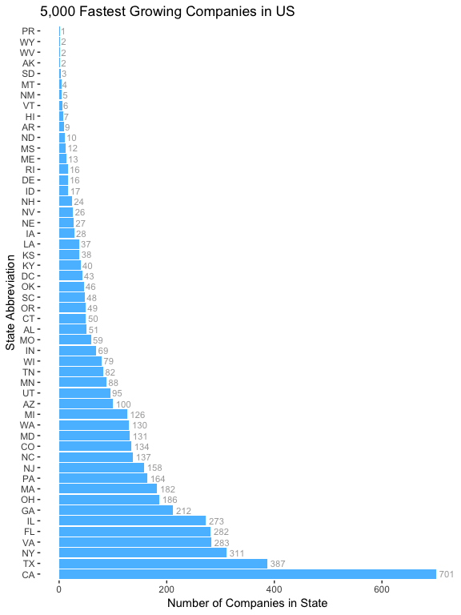

```r
# option 2 using forcats library
library(forcats)
ggplot(inc, aes(x=fct_infreq(State))) +
    geom_bar(fill = "#58BFFF", stat="count") +
    coord_flip() +
    geom_text(aes(label=..count..), stat="count", size=3,
              hjust=-0.2, color="darkgray") +
    xlab("State Abbreviation") +
    ylab("Number of Companies in State") +
    ggtitle("5,000 Fastest Growing Companies in US") +
    theme(panel.background = element_blank())
```

## Quesiton 2

Lets dig in on the state with the 3rd most companies in the data set. Imagine you work for the state and are interested in how many people are employed by companies in different industries. Create a plot that shows the average and/or median employment by industry for companies in this state (only use cases with full data, use R’s `complete.cases()` function.) In addition to this, your graph should show how variable the ranges are, and you should deal with outliers.

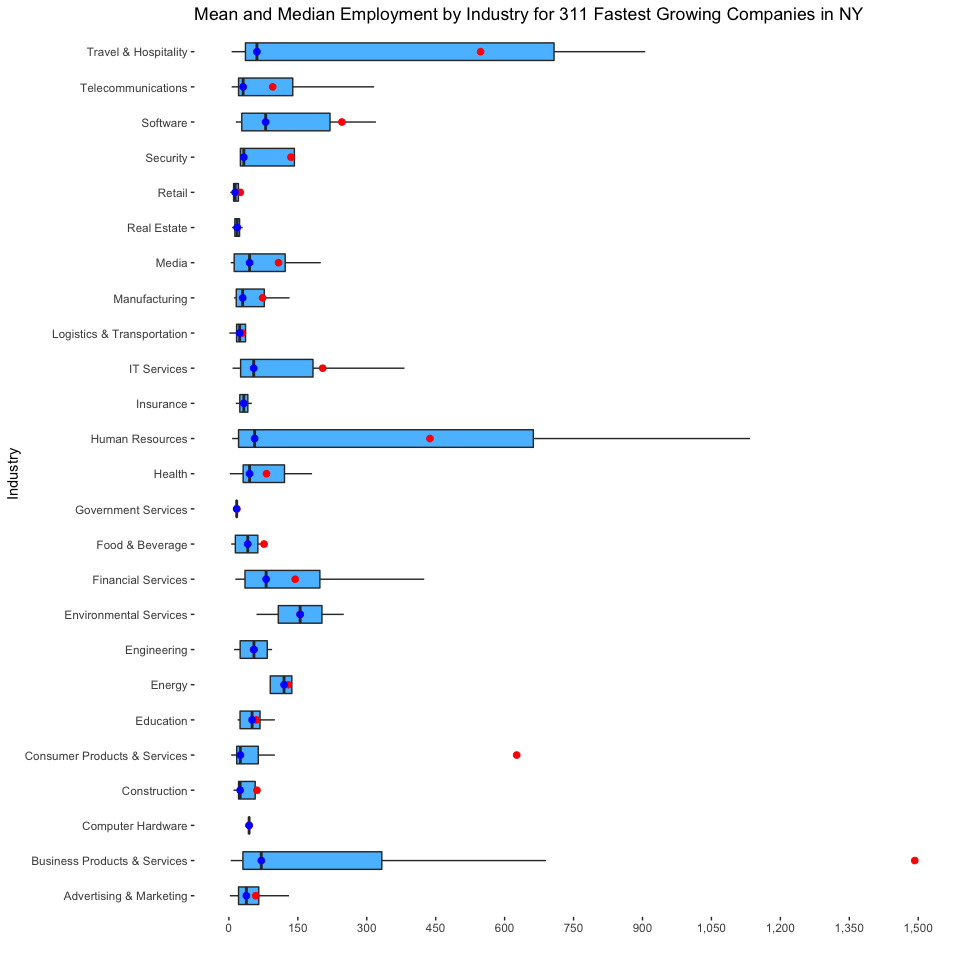

```r
NY <- subset(inc, State=="NY")
NY <- NY[complete.cases(NY), ]
ggplot(NY, aes(x=Industry, y=Employees)) +
    #geom_violin(adjust=.5, coef = 0) +
    geom_boxplot(width=.5, fill="#58BFFF", outlier.colour=NA) +
    stat_summary(aes(colour = "mean"), fun.y = mean, geom="point", fill="red",
                 colour="red", shape=21, size=2, show.legend=TRUE) +
    stat_summary(aes(colour = "median"), fun.y = median, geom="point", fill="blue",
                 colour="blue", shape=21, size=2, show.legend=TRUE) +
    # I can't for the life of me figure out how to get a legend to show what the colored points represent  :-(
    coord_flip(ylim = c(0, 1500), expand = TRUE) +
    scale_y_continuous(labels = scales::comma,
                       breaks = seq(0, 1500, by = 150)) +
    xlab("Industry") +
    ylab("") +
    ggtitle("Mean and Median Employment by Industry for 311 Fastest Growing Companies in NY") +
    theme(panel.background = element_blank(), legend.position = "top")
```

## Question 3

Now imagine you work for an investor and want to see which industries generate the most revenue per employee. Create a chart that makes this information clear. Once again, the distribution per industry should be shown.

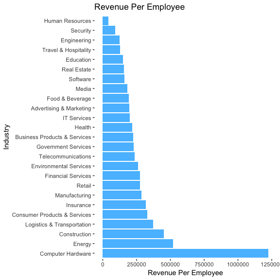

```r
library(dplyr)
revenue <-inc[complete.cases(inc),] %>%
                      group_by(Industry) %>%
                      summarise(sumR=sum(Revenue),sumE=sum(Employees)) %>%
                      mutate(rev_per_emp = sumR/sumE)
ggplot(revenue, aes(x=reorder(Industry, -rev_per_emp),y=rev_per_emp)) +
    geom_bar(fill = "#58BFFF", stat="identity") +
    coord_flip() +
    xlab("Industry") +
    ylab("Revenue Per Employee") +
    ggtitle("Revenue Per Employee") +
    theme(panel.background = element_blank(), legend.position = "top")
```